# Visualization 3

Javier Loh Hsien Siang, DFI 04, P1724226

22 July, 2019

## Singaporeans’ HDB predicament: HDB dilemma for the future

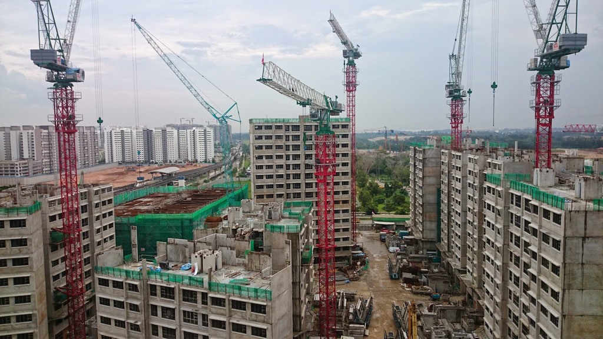

The problem:

- A: If HDB prices were to drop back to the early 2000s, home owners would potentially lose half their asset value
- B: If HDB prices were to keep increasing, will the future generations be able to afford houses?

```r
#Level 1
data <- read.csv("./Datasets/PopulationData.csv")

#Find population change from 2000 to 2015
population2000 <- data[4,2]
population2015 <- data[6,2]

#Population change
no_population <- population2015-population2000
no_population
```

```
## [1] 1518000
```

```r
population_change <- ((population2015-population2000)/population2000)*100
population_change
```

```
## [1] 37.7894
```

```r
#The population change was 37.7894% from 2000 to 2015

#Housing Shortage
housing2000 <- data[4,3]
housing2015 <- data[6,3]

no_housing <- housing2015-housing2000
housing_change <- ((housing2015-housing2000)/housing2000)*100
housing_change
```

```
## [1] 24.68334
```

```r
#Ratio of new population
no_population/no_housing
```

```
## [1] 5.9152
```

```r
#Ratio = 5.9152
```

Level 1 Findings: Definition of the ratio is to evaluate on average, how many (new) people (new people being the increase in population) will accomodate every new HDB after 2000.

Using View(data), we can see that the persons per dwelling units(PDU) is 4.3. However, the ratio exceeds the PDU.

In comparison too, the PDU in 2000 is lower than 2015. **Singaporeans were actually worse off in 2015 than compared to 2000.**

[interactive chart not shown]

Level 2 Findings:

Findings have shown that prices have skyrocketed from 2008 onwards. On the other hand, the units completed over the years against the population growth faces a mismatch, as there are more Singaporeans than available HDBs. This supply and demand forced the prices to increase drastically.